# churn

```python
import pandas as pd
from sklearn.model_selection import train_test_split
```

```python
df = pd.read_csv('churn.csv')
```

```python
df.head()
```

|  | Customer_ID | Gender | Age | Marital_status | Children | Tenure_months | Monthly_charges | Total_charges | Phone | Internet | Contract | Paperless_billing | Payment_method | Churn |
| --- | --- | --- | --- | --- | --- | --- | --- | --- | --- | --- | --- | --- | --- | --- |
| 0 | 1 | Female | 50 | 1.0 | NaN | 8 | 94.20 | 777.3 | Yes | Fiber | Monthly | Yes | Electronic check | Yes |
| 1 | 2 | Male | 70 | 1.0 | NaN | 24 | 78.85 | 1772.25 | Yes | Fiber | Monthly | Yes | Electronic check | Yes |
| 2 | 3 | Male | 73 | NaN | NaN | 47 | 20.05 | 951.55 | Yes | No | Yearly | No | Mailed check | No |
| 3 | 4 | Male | 37 | NaN | NaN | 17 | 93.85 | 1625.65 | Yes | Fiber | Monthly | No | Electronic check | Yes |
| 4 | 5 | Female | 71 | NaN | 1.0 | 32 | 79.50 | 2665 | Yes | Fiber | Monthly | Yes | Electronic check | No |

#### We can see that there are numeric, binary and categorical variables

# types

```python
# before creating the model we need to check types of all variables
df.dtypes
```

```
Customer_ID            int64
Gender                object
Age                    int64
Marital_status       float64
Children             float64
Tenure_months          int64
Monthly_charges      float64
Total_charges         object
Phone                 object
Internet              object
Contract              object
Paperless_billing     object
Payment_method        object
Churn                 object
dtype: object
```

```python
# type of 'Total_charges' needs to be changed to float, for categorical variables we will use 1-hot-encoding
df['Total_charges'] = df['Total_charges'].astype(float)
```

[output not shown]

[output cut: 9 more lines]

[output not shown]

#### Above error means that there are strings (' ') instead of numbers in some rows

```python
# we can now examine all those rows
df.loc[df['Total_charges'] == ' ']
```

|  | Customer_ID | Gender | Age | Marital_status | Children | Tenure_months | Monthly_charges | Total_charges | Phone | Internet | Contract | Paperless_billing | Payment_method | Churn |
| --- | --- | --- | --- | --- | --- | --- | --- | --- | --- | --- | --- | --- | --- | --- |
| 248 | 249 | Female | 27 | NaN | 0.0 | 0 | 52.55 |  | No | DSL | Biyearly | Yes | Bank transfer (automatic) | No |
| 920 | 921 | Male | 58 | 1.0 | 1.0 | 0 | 20.25 |  | Yes | No | Biyearly | No | Mailed check | No |
| 2453 | 2454 | Female | 53 | 0.0 | NaN | 0 | 56.05 |  | No | DSL | Biyearly | No | Credit card (automatic) | No |
| 3307 | 3308 | Female | 44 | NaN | NaN | 0 | 20.00 |  | Yes | No | Biyearly | No | Mailed check | No |
| 3664 | 3665 | Male | 69 | 0.0 | NaN | 0 | 19.85 |  | Yes | No | Biyearly | No | Mailed check | No |
| 4424 | 4425 | Female | 61 | NaN | NaN | 0 | 80.85 |  | Yes | DSL | Biyearly | No | Mailed check | No |
| 4739 | 4740 | Female | 63 | 0.0 | 1.0 | 0 | 73.35 |  | Yes | DSL | Biyearly | No | Mailed check | No |
| 5066 | 5067 | Male | 40 | NaN | 1.0 | 0 | 19.70 |  | Yes | No | Yearly | Yes | Mailed check | No |
| 5542 | 5543 | Male | 65 | NaN | 0.0 | 0 | 25.35 |  | Yes | No | Biyearly | No | Mailed check | No |
| 6096 | 6097 | Male | 76 | NaN | NaN | 0 | 25.75 |  | Yes | No | Biyearly | No | Mailed check | No |
| 6658 | 6659 | Male | 43 | 1.0 | 0.0 | 0 | 61.90 |  | Yes | DSL | Biyearly | Yes | Bank transfer (automatic) | No |

#### All elements with blank 'Total_charges' have 'Tenure_months' = 0, we will assume that these are customers that joined recently and their Total_charges should be equal to 0

```python
df['Total_charges'].replace({' ':0}, inplace=True)
```

```python
df['Total_charges'] = df['Total_charges'].astype(float)
```

# missing values

```python
# check percentage of missing values
df.isna().sum()*100/len(df)
```

```
Customer_ID           0.000000
Gender                0.000000
Age                   0.000000
Marital_status       44.782053
Children             44.583274
Tenure_months         0.000000
Monthly_charges       0.000000
Total_charges         0.000000
Phone                 0.000000
Internet              0.000000
Contract              0.000000
Paperless_billing     0.000000
Payment_method        0.000000
Churn                 0.000000
dtype: float64
```

#### There are two variables with almost 45% of missing values. This number is too big to simply remove rows with missing values. Another approach is to impute 0 and 1 with respect to ratio of classes in existing values, but this is also not perfect. The records with missing values may represent a non-homogeneous subset of the overall population, and have different statistical properties from the overall data. Considering the large amount of missing data, we will remove both columns. As an alternative we could consider applying more advanced methods of imputing missing data, but it requires additional analysis.

```python
# we will also remove 'Customer_ID' column as it will not be useful for modelling
df = df.drop(['Marital_status', 'Children', 'Customer_ID'], axis = 1)
```

# looking for outliers

```python
# now we will use describe method to get understanding of numeric data and check if there are outliers
df.describe()
```

|  | Age | Tenure_months | Monthly_charges | Total_charges |
| --- | --- | --- | --- | --- |
| count | 7043.000000 | 7043.000000 | 7043.000000 | 7043.000000 |
| mean | 50.503337 | 32.371149 | 64.761692 | 2279.734304 |
| std | 17.300733 | 24.559481 | 30.090047 | 2266.794470 |
| min | 21.000000 | 0.000000 | 18.250000 | 0.000000 |
| 25% | 36.000000 | 9.000000 | 35.500000 | 398.550000 |
| 50% | 50.000000 | 29.000000 | 70.350000 | 1394.550000 |
| 75% | 66.000000 | 55.000000 | 89.850000 | 3786.600000 |
| max | 80.000000 | 72.000000 | 118.750000 | 8684.800000 |

#### Values increase gradually and there are no significant differences between mean and min/max values

# encoding

```python
# at first, we will change target variable to 0 and 1
df['Churn'] = df['Churn'].map({'Yes': 1, 'No': 0})
```

```python
# now we will change each categorical variable into few binary
df = pd.get_dummies(df)
```

```python
df2 = df.tail(100).reset_index()
df1 = df[:-100]
```

```python
y = df1['Churn']
```

```python
x = df1 = df1.drop(['Churn'], axis = 1)
```

```python
# splitting the data into training and test sets with the same proportions of target classes
x_train, x_test, y_train, y_test = train_test_split(x, y, test_size=0.2, stratify=y, random_state = 0)
```

```python
from sklearn.tree import DecisionTreeClassifier
from sklearn.metrics import classification_report
```

```python
# creating model for default hyperparameters
dt = DecisionTreeClassifier()
dt.fit(x_train, y_train)
```

```
DecisionTreeClassifier()
```

```python
print(dt.score(x_train, y_train))
print(dt.score(x_test, y_test))
```

```
0.999819949585884
0.7105831533477321
```

```python
print(classification_report(y_test, dt.predict(x_test)))
```

```
              precision    recall  f1-score   support

           0       0.81      0.80      0.80      1021
           1       0.46      0.47      0.46       368

    accuracy                           0.71      1389
   macro avg       0.63      0.63      0.63      1389
weighted avg       0.71      0.71      0.71      1389
```

#### Accuracy is much bigger for train than for test set. This means that model is overfitting and does not work well for new data. Accuracy itself can be a misleading measure, especially for imbalanced classification. Because of that, it is important to take into consideration precision and recall for both classes as well. Results are much better for class with label 0. Unfortunately, the model correctly classifies customers as those who will leave in only half of the cases. It also found only half of them. To improve performance of the model, we will use grid search method to tune hyperparameters.

```python
# for grid search some parts of a code from two blogs were used:
# https://plainenglish.io/blog/hyperparameter-tuning-of-decision-tree-classifier-using-gridsearchcv-2a6ebcaffeda
# https://www.projectpro.io/recipes/optimize-hyper-parameters-of-decisiontree-model-using-grid-search-in-python#mcetoc_1g1ajorna7
from sklearn.model_selection import GridSearchCV
```

```python
param_dict = {'criterion': ['gini', 'entropy'], 'max_depth': range(2,11)}
```

```python
dt2 = GridSearchCV(DecisionTreeClassifier(), param_dict)
dt2.fit(x, y)
```

```
GridSearchCV(estimator=DecisionTreeClassifier(),
             param_grid={'criterion': ['gini', 'entropy'],
                         'max_depth': range(2, 11)})
```

```python
# best parameters from the grid
print('Best Criterion:', dt2.best_estimator_.get_params()['criterion'])
print('Best max_depth:', dt2.best_estimator_.get_params()['max_depth'])
```

```
Best Criterion: entropy
Best max_depth: 5
```

```python
print(dt2.score(x_train, y_train))
print(dt2.score(x_test, y_test))
```

```
0.7978033849477854
0.8092152627789777
```

```python
print(classification_report(y_test, dt2.predict(x_test)))
```

```
              precision    recall  f1-score   support

           0       0.88      0.86      0.87      1021
           1       0.64      0.66      0.65       368

    accuracy                           0.81      1389
   macro avg       0.76      0.76      0.76      1389
weighted avg       0.81      0.81      0.81      1389
```

#### This time accuracy does not differ between two datasets. It also increased from 71% to 81% for test set. Precision and recall are now better for both classes. To show exact results we will create a confusion matrix.

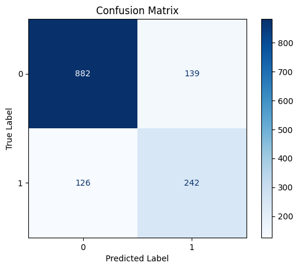

```python
#chart based on code from https://www.jcchouinard.com/confusion-matrix-in-scikit-learn/
import matplotlib.pyplot as plt
from sklearn.metrics import plot_confusion_matrix
from sklearn.metrics import confusion_matrix

cm = confusion_matrix(y_test, dt2.predict(x_test))
cm

matrix = plot_confusion_matrix(dt2, x_test, y_test, cmap=plt.cm.Blues)
matrix.ax_.set_title('Confusion Matrix')
plt.xlabel('Predicted Label')
plt.ylabel('True Label')
plt.gcf().axes[0].tick_params()
plt.gcf().axes[1].tick_params()
plt.show()
```

#### The model in this form is quite good at detecting clients that are not going to churn. However, from business perspective it could be more important to find more people with high possibility of leaving. It would allow targeting them with appropriate marketing campaign. We can change the model to work this way by adjusting its weights for both classes.

#### According to: https://machinelearningmastery.com/cost-sensitive-decision-trees-for-imbalanced-classification/ the best practice for using the class weighting is to use the inverse of the class distribution present in the training dataset.

```python
y_train.value_counts()
```

```
0    4083
1    1471
Name: Churn, dtype: int64
```

```python
dt3 = DecisionTreeClassifier(max_depth = dt2.best_estimator_.get_params()['max_depth'], criterion = dt2.best_estimator_.get_params()['criterion'], class_weight = {0: 1, 1: 2.78})
dt3.fit(x_train, y_train)
```

```
DecisionTreeClassifier(class_weight={0: 1, 1: 2.78}, criterion='entropy',
                       max_depth=5)
```

```python
print(dt3.score(x_train, y_train))
print(dt3.score(x_test, y_test))
```

```
0.7364061937342455
0.7300215982721382
```

```python
print(classification_report(y_test, dt3.predict(x_test)))
```

```
              precision    recall  f1-score   support

           0       0.93      0.68      0.79      1021
           1       0.49      0.86      0.63       368

    accuracy                           0.73      1389
   macro avg       0.71      0.77      0.71      1389
weighted avg       0.82      0.73      0.75      1389
```

#### Although the model with changed weights has lower accuracy, it may be more appropriate in this case. The recall of 0.86 for class y = 1 means that 86% of all churns from the test set were correctly classified. Confusion matrix will allow visualizing it more precisely.

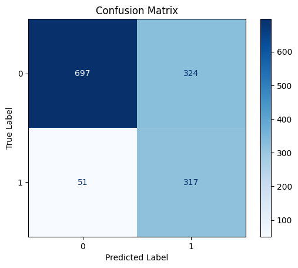

```python
cm = confusion_matrix(y_test, dt3.predict(x_test))
cm

matrix = plot_confusion_matrix(dt3, x_test, y_test, cmap=plt.cm.Blues)
matrix.ax_.set_title('Confusion Matrix')
plt.xlabel('Predicted Label')
plt.ylabel('True Label')
plt.gcf().axes[0].tick_params()
plt.gcf().axes[1].tick_params()
plt.show()
```

#### As a result of using this model, only 51 of the leaving customers were omitted. It's crucial to make the number of false negative predictions as small as possible if we want to maximize the reach of campaign among the right customers. It's also important to notice that 324 customers that didn't leave were misclassified which would have consequence of additional cost of unnecessary actions. The right approach may differ in specific cases and should be chosen based on the selected strategy.

#### Decision trees not only give good results but can be also easily interpreted. In addition, we can visualize the created model to check what criteria were used for splitting the data.

```python
from sklearn import tree
text_representation = tree.export_text(dt3)
print(text_representation)
```

```
|--- feature_12 <= 0.50
|   |--- feature_9 <= 0.50
|   |   |--- feature_11 <= 0.50
|   |   |   |--- feature_8 <= 0.50
|   |   |   |   |--- feature_0 <= 27.50
|   |   |   |   |   |--- class: 0
|   |   |   |   |--- feature_0 >  27.50
|   |   |   |   |   |--- class: 0
|   |   |   |--- feature_8 >  0.50
|   |   |   |   |--- feature_0 <= 60.50
|   |   |   |   |   |--- class: 0
|   |   |   |   |--- feature_0 >  60.50
|   |   |   |   |   |--- class: 0
|   |   |--- feature_11 >  0.50
|   |   |   |--- feature_0 <= 79.50
|   |   |   |   |--- feature_1 <= 45.50
|   |   |   |   |   |--- class: 0
|   |   |   |   |--- feature_1 >  45.50
|   |   |   |   |   |--- class: 0
|   |   |   |--- feature_0 >  79.50
|   |   |   |   |--- feature_5 <= 0.50
|   |   |   |   |   |--- class: 1
|   |   |   |   |--- feature_5 >  0.50
|   |   |   |   |   |--- class: 0
|   |--- feature_9 >  0.50
|   |   |--- feature_1 <= 70.50
|   |   |   |--- feature_11 <= 0.50
|   |   |   |   |--- feature_2 <= 99.17
|   |   |   |   |   |--- class: 0
|   |   |   |   |--- feature_2 >  99.17
|   |   |   |   |   |--- class: 1
|   |   |   |--- feature_11 >  0.50
|   |   |   |   |--- feature_0 <= 62.50
|   |   |   |   |   |--- class: 0
|   |   |   |   |--- feature_0 >  62.50
|   |   |   |   |   |--- class: 0
|   |   |--- feature_1 >  70.50
|   |   |   |--- feature_3 <= 8678.62
|   |   |   |   |--- feature_18 <= 0.50
|   |   |   |   |   |--- class: 0
```

[output cut: 36 more lines]

```
|   |   |   |   |--- feature_2 <= 80.58
|   |   |   |   |   |--- class: 1
|   |   |   |   |--- feature_2 >  80.58
|   |   |   |   |   |--- class: 1
|   |   |--- feature_1 >  15.50
|   |   |   |--- feature_1 <= 54.50
|   |   |   |   |--- feature_18 <= 0.50
|   |   |   |   |   |--- class: 1
|   |   |   |   |--- feature_18 >  0.50
|   |   |   |   |   |--- class: 1
|   |   |   |--- feature_1 >  54.50
|   |   |   |   |--- feature_2 <= 96.70
|   |   |   |   |   |--- class: 0
|   |   |   |   |--- feature_2 >  96.70
|   |   |   |   |   |--- class: 1
```

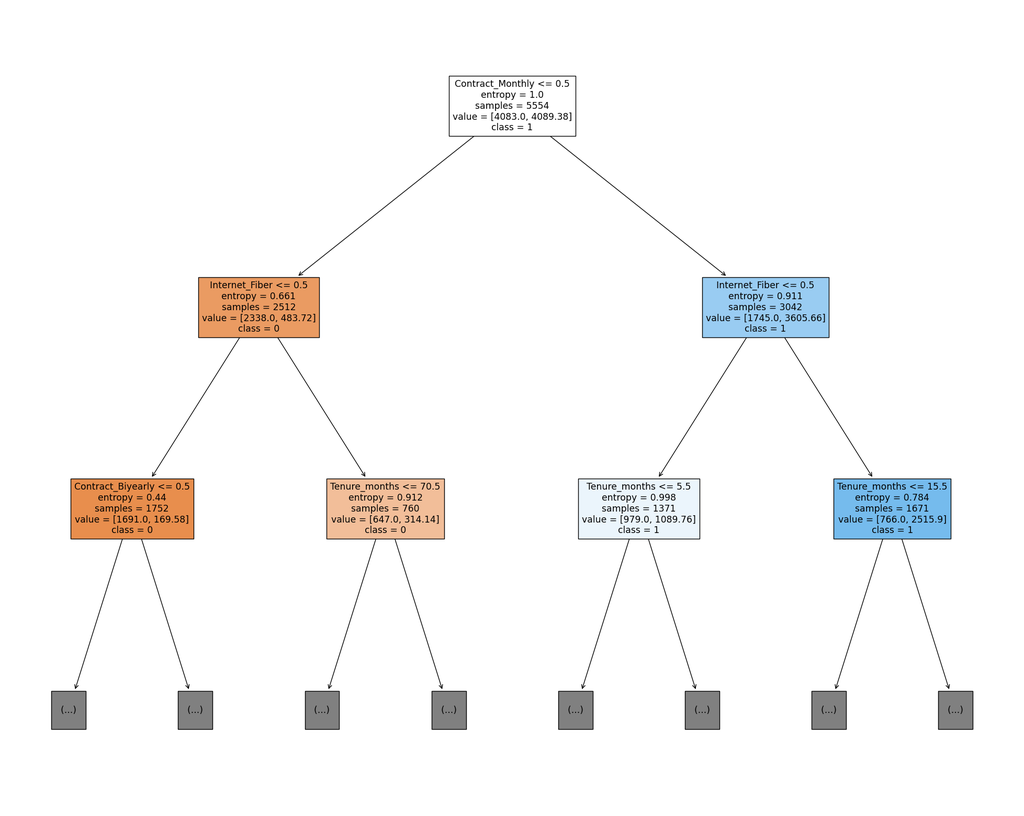

```python
fig = plt.figure(figsize=(25,20))
_ = tree.plot_tree(dt3,
                   feature_names=x.columns,
                   class_names=["0","1"],
                   max_depth = 2,
                   filled=True)
```

#### As we can see, most of the customers with monthly contract and internet fiber have high possibility of leaving, especially if they have been present for less than 16 months. On the other hand, most of those with different type of contract and internet are very likely to stay.

```python
# final predictions based on seperated sample
y2 = df2['Churn']
x2 = df2 = df2.drop(['Churn', 'index'], axis = 1)
predictions = dt3.predict(x2)
predictions
```

```
array([0, 0, 0, 1, 0, 0, 0, 1, 0, 0, 0, 0, 0, 0, 0, 1, 1, 1, 0, 1, 1, 0,
       0, 0, 0, 1, 0, 1, 0, 1, 0, 1, 1, 0, 1, 1, 0, 1, 0, 1, 0, 0, 1, 1,
       1, 0, 0, 0, 0, 0, 0, 0, 0, 0, 1, 0, 0, 1, 0, 1, 1, 1, 0, 1, 0, 1,
       0, 1, 1, 1, 0, 1, 1, 1, 0, 0, 0, 0, 0, 0, 1, 0, 1, 1, 0, 0, 1, 1,
       1, 0, 1, 1, 1, 0, 1, 0, 0, 0, 0, 0])
```